# Effective Smoke Detector Outreach

Predicting Fire Risk in Louisville, KY

Rachael Hartofelis, Yixuan Hu, Mayu Tanaka

May 2, 2019

[Return to MUSA 801 Projects Page](https://pennmusa.github.io/MUSA_801.io/)

This project was produced as a part of the University of Pennsylvania’s Master of Urban Spatial Analytics Spring 2019 Practicum (MUSA 801). The course was instructed by Ken Steif, Michael Fichman, and Matthew Harris, for whom we’d like to thank for their guidance. The group would also like to thank the City of Louisville for the opportunity to work on this project. Louisville Data Officer Michael Schnuerle, and to Major Joseph Williams of the Louisville Fire Department were integral partners in the development of this work.

This document is intended to enable others to replicate the methodology of a study of structural fires. Products of this course should be considered works in progress. We first introduce the context of this project, followed by the data, methodology, modeling, and guiding appendices. A table of contents is provided for easy navigation, along with select hyperlinks throughout the document.

# 1 Introduction

## 1.1 Abstract

Building fires are a relatively rare occurrence, but fire risk, particularly in an older city like Louisville, KY, is omnipresent. This project seeks to predict geospatial fire risk in Louisville, and to use this risk to help inform a smoke detector outreach program. By utilizing a variety of sources, including fire data, property data, and environmental variables, the model assigns a risk score throughout different areas of the city, which can be used to identify the highest risk areas for latent fire risk. While Louisville currently has a smoke detector program, through which citizens can request a smoke detector via 311, the model results illustrate vulnerabilities in the city’s current system. This work can help to direct efforts to mitigate potential fires in at-risk communities, and public locations throughout the city could be utilized for extended smoke detector programming efforts.

## 1.2 Motivation

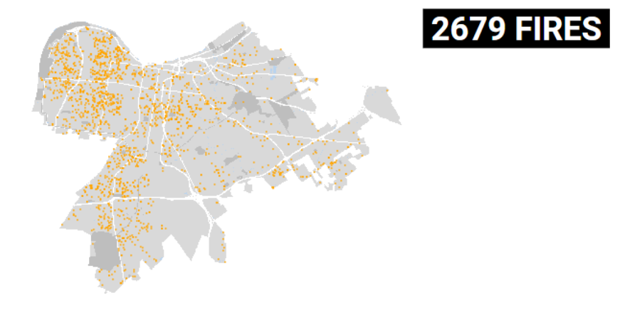

Fires, as with many environmental risks, are rare enough that they are often disregarded - at least, until directly affected by one. However, there has been an increase of fire events in the city of Louisville in recent years, and more residents are at risk than ever.

Currently, the city mitigates residential fire risk through three main approaches: 21 fire stations service the central part of the city; the city’s inspection system targets a number of residential properties throughout the year; and a focused outreach program provides smoke detectors to residents who call 311 to request installation. We believe there is an opportunity in this final category to establish a more effective system. Relying primarily on inspections can be costly and difficult to arrange for residential properties, but smoke detector outreach can be expounded upon with less manpower, and applied to a broader scope. Last year, there were 700 installations, but we believe that we can help the city not just to increase this quantity, but to get these assets to those who need it most.

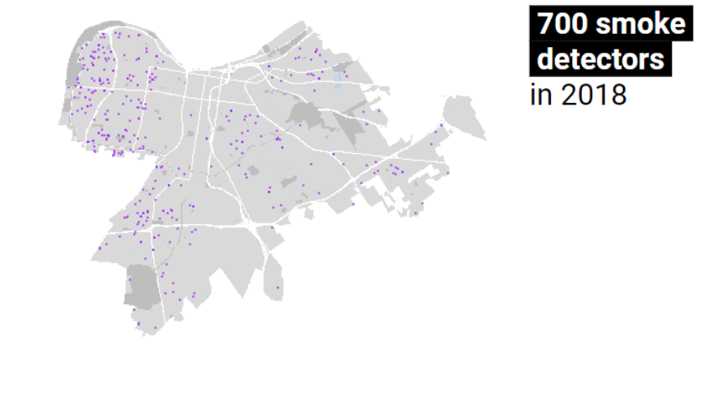

To do so, we have built an algorithm that predicts fire risk, with an emphasis on latent risk, rather than depending only on previous occurrences. We have sought to identify where future fires may occur, so that Louisville can mitigate the risk before the fire ever starts.

## 1.3 Data

We compiled the following data for our analysis: environmental data from Louisville’s Open Data website, fire data from the Louisville Fire Department, and property valuation data from the City of Louisville. For further details on these sources, please see Appendix: Data Dictionary.

The data was also “wrangled” before being explored in the following section. This process included various transformations of the data in order to optimize predictive ability of each variable. For details on this procedure, please see Feature Engineering and Appendix: Data Wrangling. Through exploratory analysis and the modeling process, the final dataset was narrowed down to a set of best predictors. For results on how the data ultimately performed in the models, please see Model Building.

## 1.4 Modeling Strategy

This report seeks to create a model that will predict fire risk throughout the city, even if fires have not previously occurred there. However, traditional spatial models simply interpolate across space, assuming that past events are the best indicator of general risk. A kernel density map, also known as a “hotspot map”, is an example of this. The map below illustrates the kernel density alongside a map where fire events are counted for each 500 x 500 grid cell citywide.

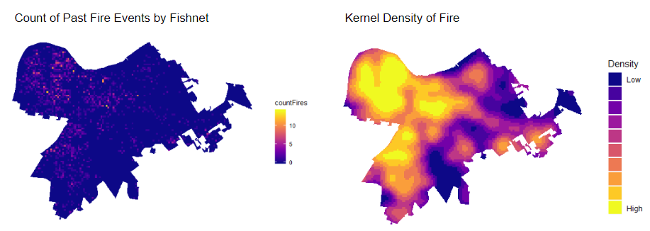

A spatial risk model is an alternative approach that utilizes neighborhood, environmental, and demographic variables to help identify latent risk; it does not assume that past fires are the best indication of future ones and therefore allows risk to vary across the city. In order to best account for this variation, the city was divided into 500 x 500 foot grid cells, translating to a city block level unit of analysis. Together, the grid cells form a “fishnet.”

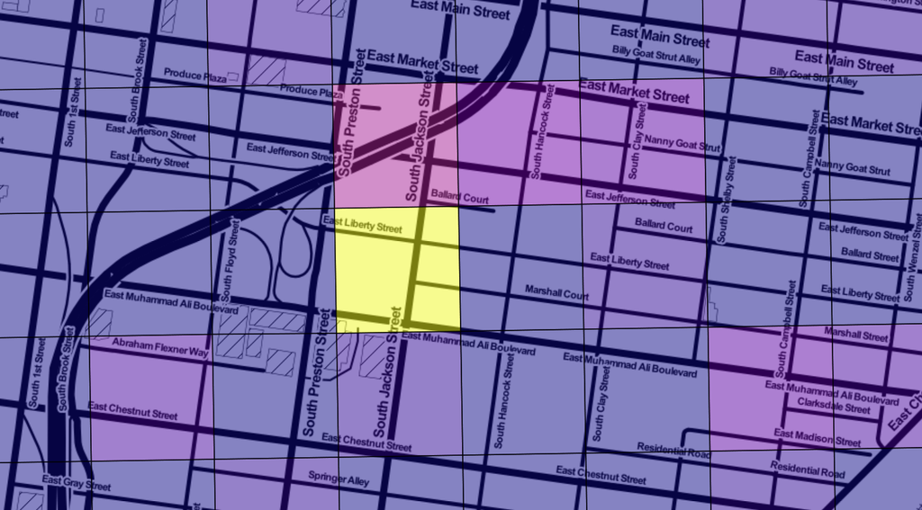

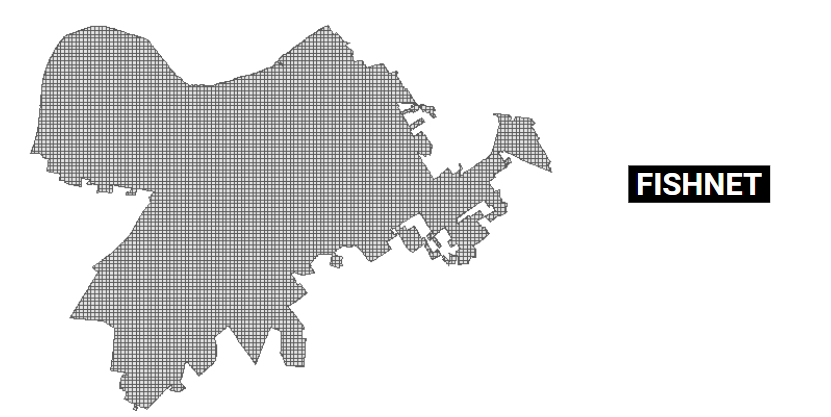

Mapping fires to the fishnet clearly conveys the rarity of such an event, with only 16% percent of grid cells containing at least one fire. This observation subsequently shaped our modeling approach.

Other variables were also added to the fishnet, so that each grid cell contained neighborhood, environmental, and demographic characterstics, as well as data about past fires. Yet, while inclusion of a plenitude of variables thoroughly illustrates past experiences, a critical objective of this report is to balance both the accuracy and generalizability of our predictions. If our model is too accurate, it may overly correlate with past fires, therefore obscuring the latent risk in areas that have not had any. Instead, our model aims to be generalizable as well as accurate, allowing it to be applied to the entire city without simply reiterating previous trends. Consequently, we divided our variables into separate “stories” or lenses through which we could explore the relationship between fires differently: a building-level story, a neighborhood story, and a demographic story. These stories are modeled separately and then combined to maximize predictive ability. In this way, we prevent any set of variables from “overfitting” the model and masking generalizability in favor of accuracy.

# 2 Exploratory Analysis

## 2.1 Feature Engineering

In order to best extrapolate the relationship between our data and the fires, we “engineered” variables to include in our dataset. Many of these variables have more explanatory power as varied spatial measurements, which began simply as a count of points within each grid cell, then were also engineered as distances, densities, and an average of the nearest neighbors. The example below shows how these measurements differ spatially:

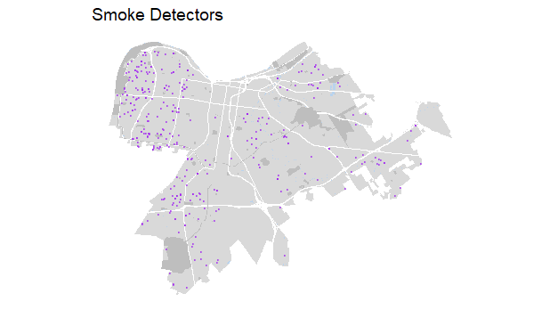

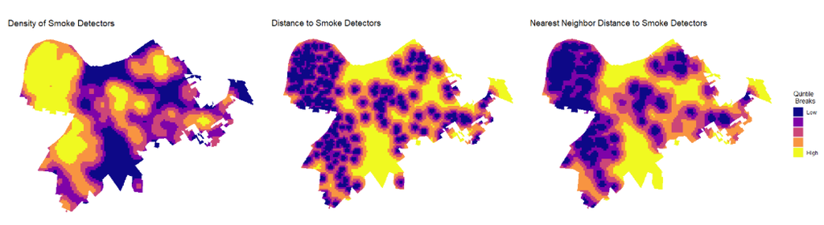

For an explanation of which measurements were used for each variable, please see Appendix: Data Dictionary.

## 2.2 Are fires related to one another?

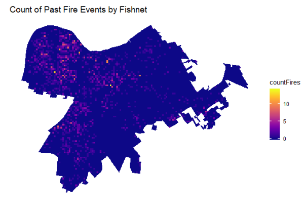

We first sought to explore the relationship between fires themselves, hypothesizing that the interrelated experience of past fires would inform us about future ones. For instance, does the presence of one fire event correspond with a higher volume of others nearby? If so, we would expect to observe clusters of fires - as opposed to a random distribution of these events across all of Louisville - and indeed, we see that this is the case in the map below. In fact, the amount of clustering is statistically significant.

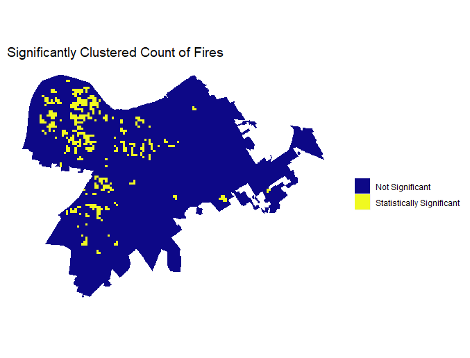

Yet, despite this clear relationship, relying too heavily on past events could undermine the ability to identify latent risk; our model could be “overfit” on occurrences of previous fires or lack thereof. Future fires are by no means limited to such trends. What else, then, are fires related to?

## 2.3 Can environmental variables predict latent risk?

The spatial clustering of fires we have identified implies that there are other factors that may contribute to the propensity of fires to occur where they have before. We thus explored the characteristics of the environment of past fires to determine whether such variables could help predict latent risk.

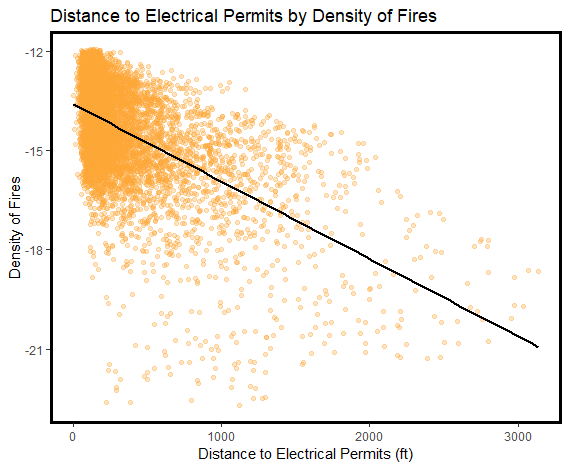

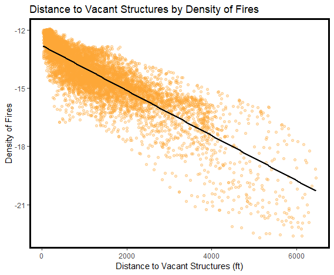

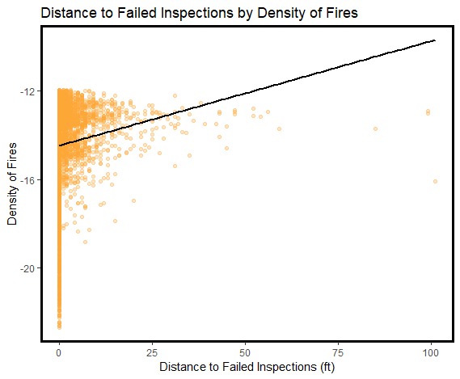

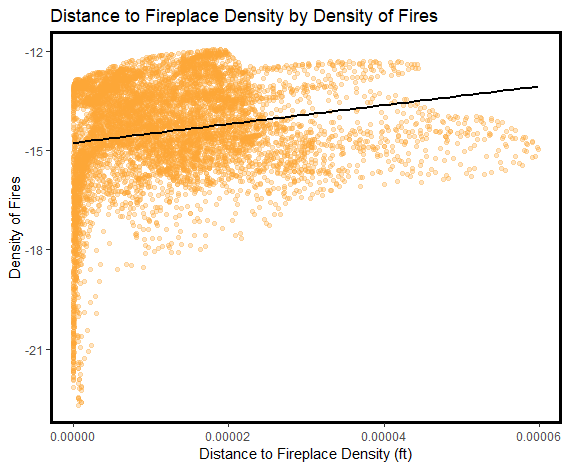

The scatter plots above show a relationship between the some of the features we engineered and the density of fires, indicating that environmental variables indeed correlate with fires. In particular, there appear to be strong correlations between electrical permits and vacant structures. Failed inspections and fireplace density tend to have slightly looser relationships. Using this analysis, we assembled an array of variables to model fires in order to assess risk.

## 2.4 Are mitigation resources properly aligned to risk?

Finally, we examined whether current mitigation resources are properly aligned to risk. As mentioned in the Introduction section, these resources include fire stations, inspections, and requests for smoke detector installation. Below, we observe that the current distribution of these services is somewhat correlated with fires such that the distance to these resources decreases with higher densities of fires. This means that they tend to be located in areas that are helpful to mitigation efforts.

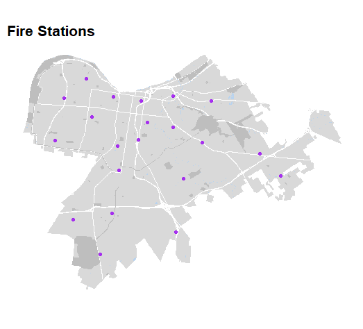

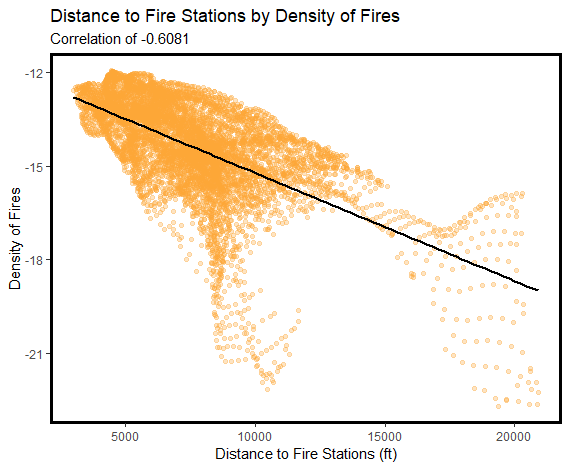

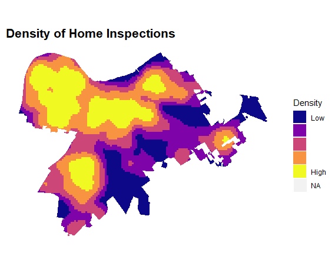

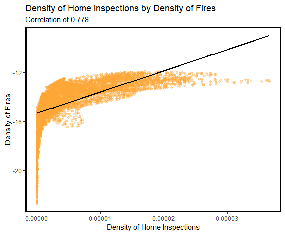

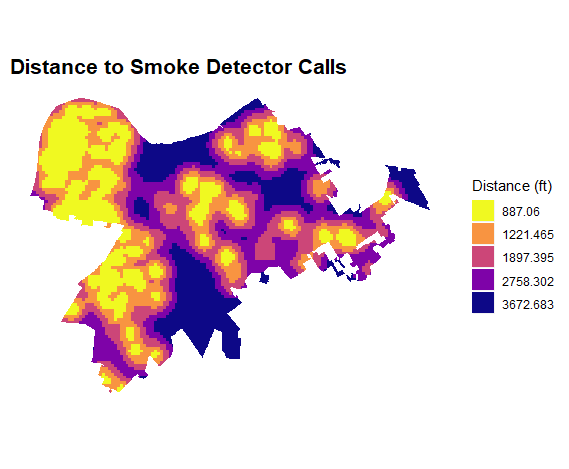

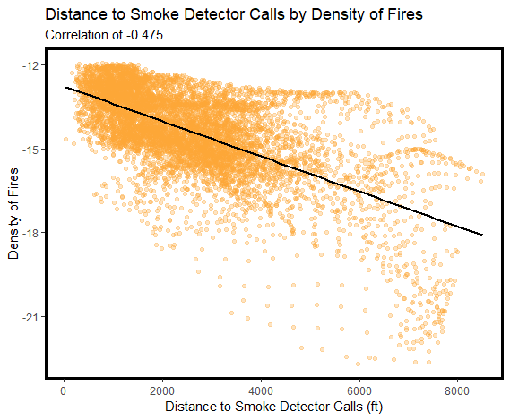

# 3 Modeling

## 3.1 Feature Selection

An important step in the modeling process is to determine which variables are the most powerful predictors. Finding stronger variables allows us to slim down the size of our dataset, making for a more efficient model. In order to find such predictors, we first identified significant variables among our entire dataset using a Poisson general linear model. We then iterated through a series of machine learning models to supplement the selection process and cross-referenced the results to see which variables showed the most predictive power. An example of this can be shown below using a eXtreme Gradient Boosting (XGB) model:

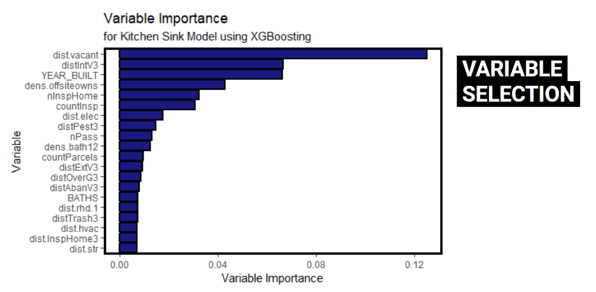

In this particular model, distance to vacancy was by far the most predictive variable, followed by interior violations, and the year in which the homes were built. As we iterated through our models, this method helped us hone in on other variables with a similar effect, indicating that homes in poor or vacant condition are associated with higher risk. Offsite owners followed closely behind, showing that potential landlord and owner negligence may correlate with fire risk.

After selecting these variables, we also wanted to ensure that they were sufficiently independent of one another in order to avoid redundancy as well as issues with multicollinearity, which would undermine the predictive ability of our model. We thus divided the variables by story and plotted the pairwise correlations.

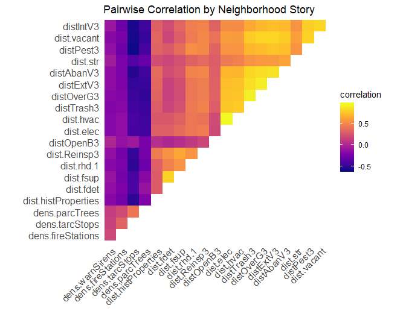

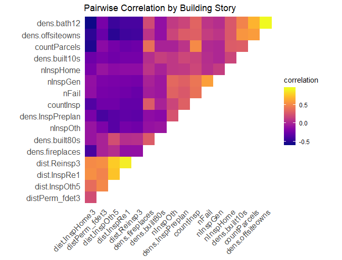

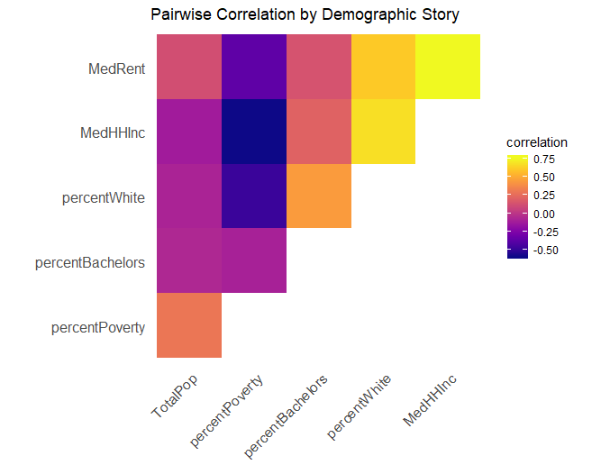

## 3.2 Ensembling

Initially, we attempted to model with all of our 202 variables. However, we quickly realized that in doing so, some of our variables were monopolizing the predictive power of the model and leading it to overfit - becoming too accurate at predicting the past fires instead of for latent risk. In order to mitigate this concern, we divided the variables into three different stories: building level, neighborhood level, and demographic elements, believing that each story told a slightly different story about what led to fire risk. By separating them, they could show their distinct relationship to fire occurrences, and therefore help to make our model more generalizable.

The predictions from each story are mapped to show the distribution of the models as predicted by each variable story. They are also validated, using both test and training sets, to show the error in their predictions. For testing, a subset of 60% of the city’s grid cells are set aside as a training set. The training dataset is then tested on the remaining 40%, which is called a test set, to see how well it predicts for those values. The error is the difference between the observed number of fires per grid cell as compared to the number that the model has predicted, showing the accuracy of the model.

### 3.2.1 The Building Story

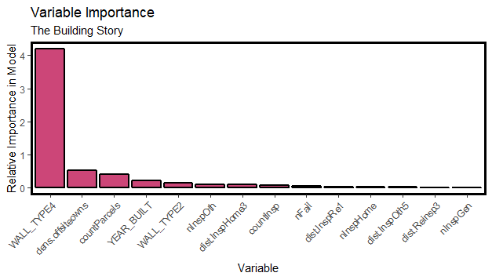

One can see that this building level scale creates a level of nuance within the predictions in the map below.

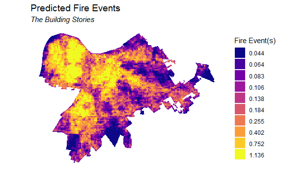

The model produces a mean absolute error of 0.374, meaning that it is accurate within 0.374 of a fire. While this relatively low error is promising, we noticed that the 1st and 5th quantile of prediction error are interspersed, which means this model has predicted fires in areas that have not seen fire occurrences in the past, therefore identifying latent risk.

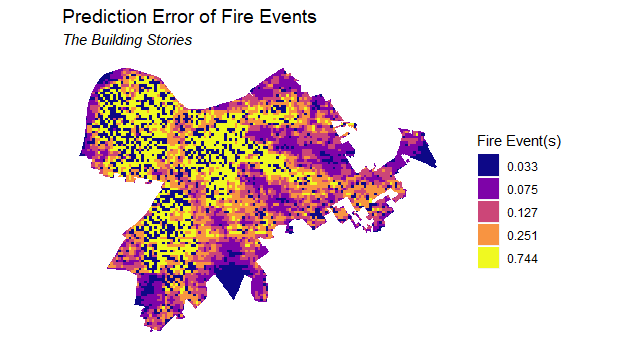

### 3.2.2 The Neighborhood Story

The neighborhood story is made up of variables that describe the build environment and landscape. Some of the best predictors in this story included the distance to electrical permits, the distance to interior violations, and the distance to vacancy. These results can help us to see that structures that need more maintenance are, not surprisingly, more likely to carry fire risk.

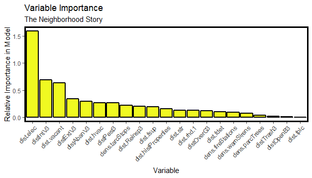

As a model, the map shows more accuracy than the building story, particularly in areas with zero previous fires, such as in the bottom left corner in a city park. This means that our neighborhood story may help us to identify places with lower better risk more accurately, helping us to avoid distributing fire detectors to areas where they would be less useful.

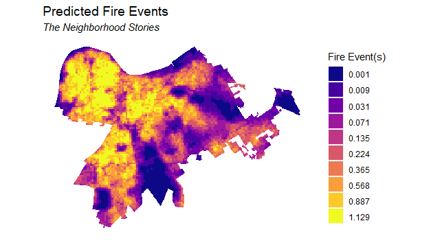

The error is also lower in this story, with its errors only accounting for 0.365 of a fire. The map below shows similar features to the previous story, with interspersion of high and low predictions in the map. However, to continue to build off of the models strengths, it is decidedly more accurate in areas with no past fires, meaning that it can add to the predictive power of our final ensemble.

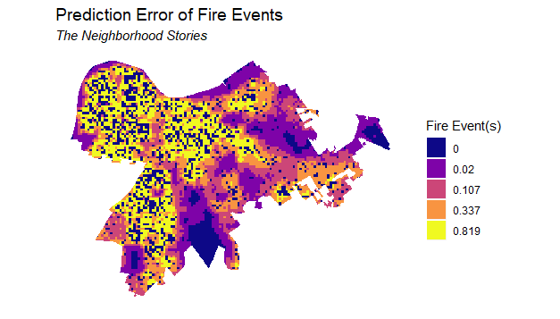

### 3.2.3 The Demographic Story

In the demographic story, we used 6 variables, including population, social status indicators, and economic indicators. The best predictors in this model included median household income, population, and median rent. Population helps us to understand that the fires occur in denser locations, and the latter two predictors seem to correlate with the need for maintenance shown in other stories. In this case, people may be struggling with the financial burden of safe upkeep.

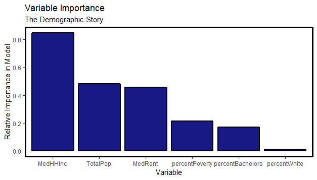

From the predicted fire map, we can see that the model generated by this story predicted the entire west area as high risk zone, meaning that the census tract boundary of this map likely obscured much of the variance needed for higher accuracy.

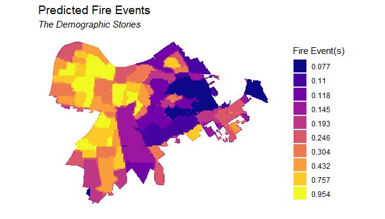

The error in this model are higher than in other stories, again, likely because of the scale of the information. In this model, it predicts within 0.428 of a fire. The map shows a starker contrast between prediction accuracy, with much of the west side, where fires are concentrated, being less accurate.

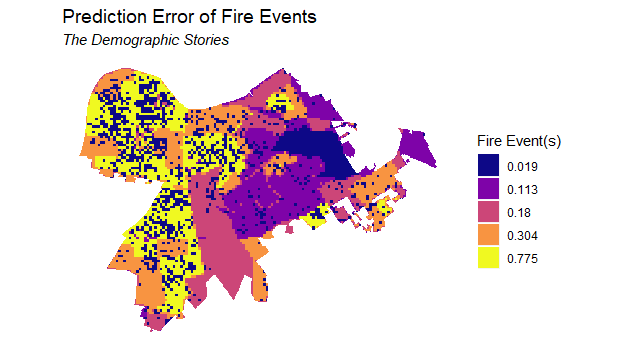